# Exploratory Data Analysis Report

Report by dlookr package

2020-08-15

# 1 Introduction

The EDA Report provides exploratory data analysis information on objects that inherit data.frame and data.frame.

## 1.1 Information of Dataset

The dataset that generated the EDA Report is an **‘data.frame’** object. It consists of **1,460 observations** and **7 variables**.

## 1.2 Information of Variables

The variable information of the data set that generated the EDA Report is shown in the following table.:

Information of Variables

| variables | types | missing_count | missing_percent | unique_count | unique_rate |
| --- | --- | --- | --- | --- | --- |
| MSSubClass | integer | 0 | 0.00000 | 15 | 0.0102740 |
| MSZoning | factor | 0 | 0.00000 | 5 | 0.0034247 |
| LotFrontage | integer | 259 | 17.73973 | 111 | 0.0760274 |
| LotArea | integer | 0 | 0.00000 | 1073 | 0.7349315 |
| Street | factor | 0 | 0.00000 | 2 | 0.0013699 |
| Alley | factor | 1369 | 93.76712 | 3 | 0.0020548 |
| SalePrice | integer | 0 | 0.00000 | 663 | 0.4541096 |

The target variable of the data is **‘SalePrice’**, and the data type of the variable is **integer**.

## 1.3 About EDA Report

EDA reports provide information and visualization results that support the EDA process. In particular, it provides a variety of information to understand the relationship between the target variable and the rest of the variables of interest.

# 2 Univariate Analysis

## 2.1 Descriptive Statistics

edaData  
7 Variables 1460 Observations

MSSubClass

| n | missing | distinct | Info | Mean | Gmd | .05 | .10 | .25 | .50 | .75 | .90 | .95 |
| --- | --- | --- | --- | --- | --- | --- | --- | --- | --- | --- | --- | --- |
| 1460 | 0 | 15 | 0.94 | 56.9 | 43.19 | 20 | 20 | 20 | 50 | 70 | 120 | 160 |

lowest : 20 30 40 45 50 , highest: 90 120 160 180 190

```
 Value         20    30    40    45    50    60    70    75    80    85    90   120
 Frequency    536    69     4    12   144   299    60    16    58    20    52    87
 Proportion 0.367 0.047 0.003 0.008 0.099 0.205 0.041 0.011 0.040 0.014 0.036 0.060

 Value        160   180   190
 Frequency     63    10    30
 Proportion 0.043 0.007 0.021
```

MSZoning

| n | missing | distinct |
| --- | --- | --- |
| 1460 | 0 | 5 |

lowest : RL RM C (all) FV RH , highest: RL RM C (all) FV RH

```
 Value           RL      RM C (all)      FV      RH
 Frequency     1151     218      10      65      16
 Proportion   0.788   0.149   0.007   0.045   0.011
```

LotFrontage

| n | missing | distinct | Info | Mean | Gmd | .05 | .10 | .25 | .50 | .75 | .90 | .95 |
| --- | --- | --- | --- | --- | --- | --- | --- | --- | --- | --- | --- | --- |
| 1201 | 259 | 110 | 0.998 | 70.05 | 24.61 | 34 | 44 | 59 | 69 | 80 | 96 | 107 |

lowest : 21 24 30 32 33 , highest: 160 168 174 182 313

LotArea

| n | missing | distinct | Info | Mean | Gmd | .05 | .10 | .25 | .50 | .75 | .90 | .95 |
| --- | --- | --- | --- | --- | --- | --- | --- | --- | --- | --- | --- | --- |
| 1460 | 0 | 1073 | 1 | 10517 | 5718 | 3312 | 5000 | 7554 | 9478 | 11602 | 14382 | 17401 |

lowest : 1300 1477 1491 1526 1533 , highest: 70761 115149 159000 164660 215245

Street

| n | missing | distinct |
| --- | --- | --- |
| 1460 | 0 | 2 |

```
 Value       Pave  Grvl
 Frequency   1454     6
 Proportion 0.996 0.004
```

Alley

| n | missing | distinct |
| --- | --- | --- |
| 91 | 1369 | 2 |

```
 Value       Grvl  Pave
 Frequency     50    41
 Proportion 0.549 0.451
```

SalePrice

| n | missing | distinct | Info | Mean | Gmd | .05 | .10 | .25 | .50 | .75 | .90 | .95 |
| --- | --- | --- | --- | --- | --- | --- | --- | --- | --- | --- | --- | --- |
| 1460 | 0 | 663 | 1 | 180921 | 81086 | 88000 | 106475 | 129975 | 163000 | 214000 | 278000 | 326100 |

lowest : 34900 35311 37900 39300 40000 , highest: 582933 611657 625000 745000 755000

## 2.2 Normality Test of Numerical Variables

### 2.2.1 Statistics and Visualization of (Sample) Data

**[ MSSubClass ]**

normality test : Shapiro-Wilk normality test

statistic : 0.80457, p-value : 9.10819E-39

skewness and kurtosis

| type | skewness | kurtosis |
| --- | --- | --- |
| original | 1.4062101 | 4.570675 |
| log transformation | 0.2322719 | 1.882137 |
| sqrt transformation | 0.7616640 | 2.864319 |

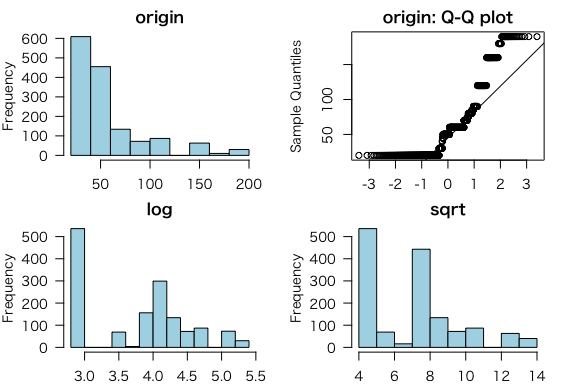

**[ LotFrontage ]**

normality test : Shapiro-Wilk normality test

```
 statistic : 0.8804,  p-value : 2.00169E-29
```

skewness and kurtosis

| type | skewness | kurtosis |
| --- | --- | --- |
| original | 2.1608660 | 20.375301 |
| log transformation | -0.7621985 | 5.339487 |
| sqrt transformation | 0.3789137 | 7.114466 |

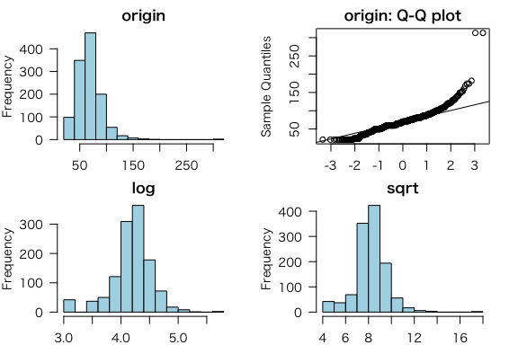

**[ LotArea ]**

normality test : Shapiro-Wilk normality test

```
 statistic : 0.35106,  p-value : 7.93365E-58
```

skewness and kurtosis

| type | skewness | kurtosis |
| --- | --- | --- |
| original | 12.195142 | 205.543793 |
| log transformation | -0.137852 | 7.693125 |
| sqrt transformation | 4.135459 | 43.383355 |

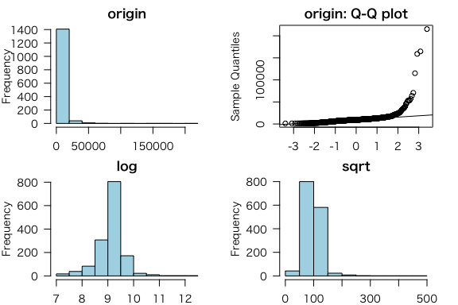

# 3 Relationship Between Variables

## 3.1 Correlation Coefficient

### 3.1.1 Correlation Coefficient by Variable Combination

```
No correlation coefficient is greater than 0.5.
```

### 3.1.2 Correlation Plot of Numerical Variables

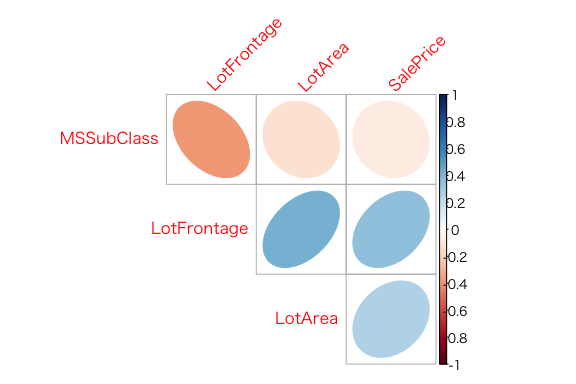

# 4 Target based Analysis

## 4.1 Grouped Descriptive Statistics

### 4.1.1 Grouped Numerical Variables

**[ MSSubClass ]**

Simple Linear Model Information

```
 Residual standard error: 79187 on 1458 degrees of freedom
 Multiple R-squared:  0.0071,   Adjusted R-squared:  0.00642
 F-statistic: 10 on 1 and 1458 DF,  p-value: 0.00126647168474951
```

Coefficients:

Simple Linear Model coefficients : MSSubClass

|  | Estimate | Std. Error | t value | Pr(>\|t\|) |
| --- | --- | --- | --- | --- |
| (Intercept) | 189927.44 | 3474.29 | 54.67 | 0 |
| MSSubClass | -158.29 | 49.01 | -3.23 | 0 |

Visualization:

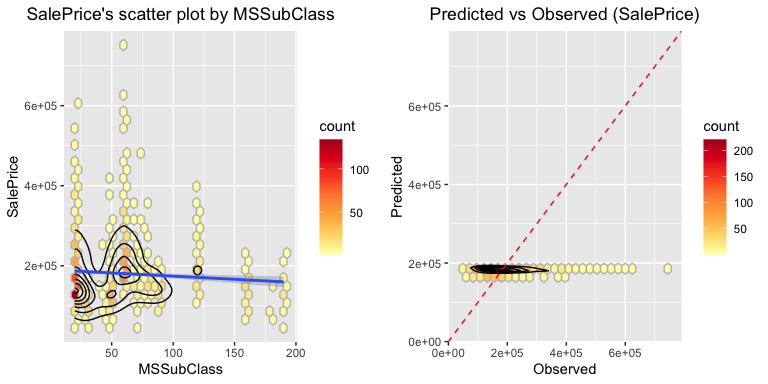

**[ LotFrontage ]**

Simple Linear Model Information

```
 Residual standard error: 78091 on 1199 degrees of freedom
 Multiple R-squared:  0.12376,  Adjusted R-squared:  0.12303
 F-statistic: 169 on 1 and 1199 DF,  p-value: 2.60244181238983e-36
```

Coefficients:

Simple Linear Model coefficients : LotFrontage

|  | Estimate | Std. Error | t value | Pr(>\|t\|) |
| --- | --- | --- | --- | --- |
| (Intercept) | 96149.04 | 6881.97 | 13.97 | 0 |
| LotFrontage | 1208.02 | 92.83 | 13.01 | 0 |

Visualization:

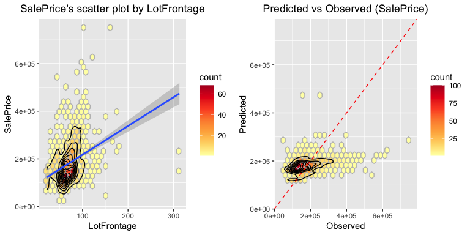

**[ LotArea ]**

Simple Linear Model Information

```
 Residual standard error: 76654 on 1458 degrees of freedom
 Multiple R-squared:  0.06961,  Adjusted R-squared:  0.06898
 F-statistic: 109 on 1 and 1458 DF,  p-value: 1.12313915491887e-24
```

Coefficients:

Simple Linear Model coefficients : LotArea

|  | Estimate | Std. Error | t value | Pr(>\|t\|) |
| --- | --- | --- | --- | --- |
| (Intercept) | 158836.1 | 2914.72 | 54.49 | 0 |
| LotArea | 2.1 | 0.20 | 10.44 | 0 |

Visualization:

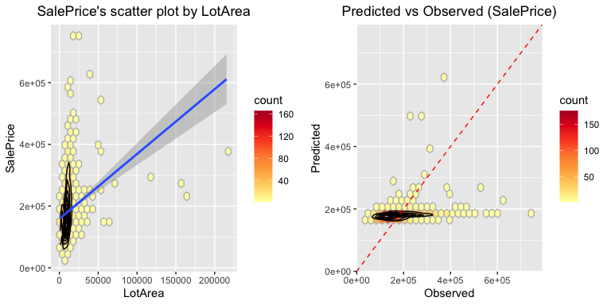

### 4.1.2 Grouped Categorical Variables

**[ MSZoning ]**  
1. Analysis of Variance

Analysis of Variance Table : MSZoning

|  | Df | Sum.Sq | Mean.Sq | F.value | Pr..F. |
| --- | --- | --- | --- | --- | --- |
| MSZoning | 4 | 9.904000e+11 | 247600007088 | 43.84 | 0 |
| Residuals | 1455 | 8.217511e+12 | 5647774094 | NA | NA |

2. Simple Linear Model Information

Residual standard error: 75152 on 1455 degrees of freedom Multiple R-squared: 0.10756, Adjusted R-squared: 0.10511 F-statistic: 44 on 4 and 1455 DF, p-value: 4.56128866166948e-30

Coefficients:

Simple Linear Model coefficients : MSZoning

|  | Estimate | Std. Error | t value | Pr(>\|t\|) |
| --- | --- | --- | --- | --- |
| (Intercept) | 191004.99 | 2215.14 | 86.23 | 0.00 |
| MSZoningRM | -64688.16 | 5551.04 | -11.65 | 0.00 |
| MSZoningC (all) | -116476.99 | 23868.06 | -4.88 | 0.00 |
| MSZoningFV | 23009.07 | 9581.01 | 2.40 | 0.02 |
| MSZoningRH | -59446.62 | 18918.05 | -3.14 | 0.00 |

3. Visualization:

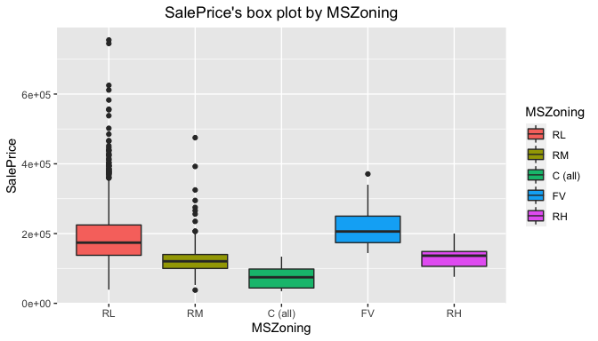

**[ Street ]**  
1. Analysis of Variance

Analysis of Variance Table : Street

|  | Df | Sum.Sq | Mean.Sq | F.value | Pr..F. |
| --- | --- | --- | --- | --- | --- |
| Street | 1 | 1.550534e+10 | 15505341615 | 2.46 | 0.12 |
| Residuals | 1458 | 9.192406e+12 | 6304805208 | NA | NA |

2. Simple Linear Model Information

Residual standard error: 79403 on 1458 degrees of freedom Multiple R-squared: 0.00168, Adjusted R-squared: 0.001 F-statistic: 2 on 1 and 1458 DF, p-value: 0.117048604067797

Coefficients:

Simple Linear Model coefficients : Street

|  | Estimate | Std. Error | t value | Pr(>\|t\|) |
| --- | --- | --- | --- | --- |
| (Intercept) | 181130.54 | 2082.35 | 86.98 | 0.00 |
| StreetGrvl | -50940.04 | 32482.87 | -1.57 | 0.12 |

3. Visualization:

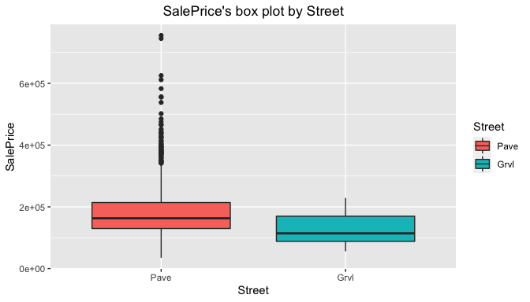

**[ Alley ]**  
1. Analysis of Variance

Analysis of Variance Table : Alley

|  | Df | Sum.Sq | Mean.Sq | F.value | Pr..F. |
| --- | --- | --- | --- | --- | --- |
| Alley | 1 | 47216371196 | 47216371196 | 35.56 | 0 |
| Residuals | 89 | 118166860566 | 1327717534 | NA | NA |

2. Simple Linear Model Information

Residual standard error: 36438 on 89 degrees of freedom Multiple R-squared: 0.2855, Adjusted R-squared: 0.27747 F-statistic: 36 on 1 and 89 DF, p-value: 4.89982616677106e-08

Coefficients:

Simple Linear Model coefficients : Alley

|  | Estimate | Std. Error | t value | Pr(>\|t\|) |
| --- | --- | --- | --- | --- |
| (Intercept) | 122219.08 | 5153.09 | 23.72 | 0 |
| AlleyPave | 45781.51 | 7677.09 | 5.96 | 0 |

3. Visualization:

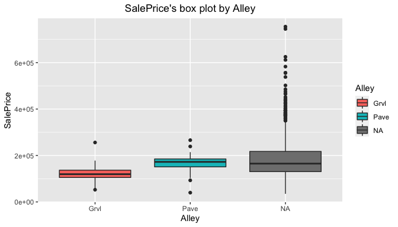

## 4.2 Grouped Relationship Between Variables

### 4.2.1 Grouped Correlation Coefficient

```
Numerical target variables are not supported.
```

### 4.2.2 Grouped Correlation Plot of Numerical Variables

```
Numerical target variables are not supported.
```